# User Behaviour Analysis & Churn Propensity (SaaS Domain)

Malika Diwakar

2026-06-27 02:10:36.512019

#### Load Libraries

```r
library(dplyr)
library(tidyverse)
library(lubridate)
library(ggplot2)
library(ggthemes)
library(plotly)
library(scales)
library(data.table)
library(tidyr)
library(janitor)
library(skimr)
library(caret)
library(randomForest)
library(xgboost)
library(pROC)
library(ROCR)
library(e1071)
```

## Data Preparation & Feature Engineering

```r
# set working directory
setwd("/Users/malika.diwakar/Desktop/Churn Analysis Project")

## import dataset
dataset <- read.csv("ChurnAnalysisData.csv", header = TRUE)

# view data structure
str(dataset)
```

```
## 'data.frame':    71391 obs. of  8 variables:
##  $ X                 : int  0 1 2 3 4 5 6 7 8 9 ...
##  $ user_id           : chr  "00X5vpkwRjYc30VF2NavgP1b7XO2" "00X5vpkwRjYc30VF2NavgP1b7XO2" "00X5vpkwRjYc30VF2NavgP1b7XO2" "00aDF58d70cbR1wu5EFbf0D0ipq2" ...
##  $ active_month      : chr  "2025-03" "2025-04" "2025-05" "2025-05" ...
##  $ first_payment_date: chr  "2022-01-20" "2022-01-20" "2022-01-20" "2025-05-01" ...
##  $ total_projects    : int  2 3 1 4 0 3 1 2 1 2 ...
##  $ culls             : int  1 2 0 4 0 0 0 0 0 0 ...
##  $ edits             : int  1 2 1 4 0 3 1 2 1 2 ...
##  $ retouchs          : int  0 0 0 0 0 0 0 0 0 0 ...
```

```r
# change date columns to DATE type
## active_month originally contains only "YYYY-MM" (therefore '-01' is added only to enable date conversion in R)
dataset$active_month <- as.Date(paste0(dataset$active_month, "-01"))
## first_payment_date
dataset$first_payment_date <- as.Date(dataset$first_payment_date)

# confirm changes have been made
str(dataset)
```

```
## 'data.frame':    71391 obs. of  8 variables:
##  $ X                 : int  0 1 2 3 4 5 6 7 8 9 ...
##  $ user_id           : chr  "00X5vpkwRjYc30VF2NavgP1b7XO2" "00X5vpkwRjYc30VF2NavgP1b7XO2" "00X5vpkwRjYc30VF2NavgP1b7XO2" "00aDF58d70cbR1wu5EFbf0D0ipq2" ...
##  $ active_month      : Date, format: "2025-03-01" "2025-04-01" ...
##  $ first_payment_date: Date, format: "2022-01-20" "2022-01-20" ...
##  $ total_projects    : int  2 3 1 4 0 3 1 2 1 2 ...
##  $ culls             : int  1 2 0 4 0 0 0 0 0 0 ...
##  $ edits             : int  1 2 1 4 0 3 1 2 1 2 ...
##  $ retouchs          : int  0 0 0 0 0 0 0 0 0 0 ...
```

```r
# remove serial no. column (not useful for analysis)
dataset <- dataset %>%
  select(-X)

# summary statistics
summary(dataset)
```

```
##       user_id       active_month        first_payment_date   total_projects
##  Length   :71391   Min.   :2024-01-01   Min.   :2021-06-10   Min.   :  0.000
##  N.unique :12175   1st Qu.:2024-11-01   1st Qu.:2023-11-02   1st Qu.:  1.000
##  N.blank  :    0   Median :2025-04-01   Median :2024-07-14   Median :  5.000
##  Min.nchar:   28   Mean   :2025-02-20   Mean   :2024-05-09   Mean   :  8.775
##  Max.nchar:   28   3rd Qu.:2025-08-01   3rd Qu.:2024-12-31   3rd Qu.: 11.000
##                    Max.   :2025-10-01   Max.   :2025-11-15   Max.   :491.000
##      culls             edits            retouchs
##  Min.   :  0.000   Min.   :  0.000   Min.   :  0.0000
##  1st Qu.:  0.000   1st Qu.:  0.000   1st Qu.:  0.0000
##  Median :  2.000   Median :  3.000   Median :  0.0000
##  Mean   :  4.746   Mean   :  5.572   Mean   :  0.3334
##  3rd Qu.:  6.000   3rd Qu.:  8.000   3rd Qu.:  0.0000
##  Max.   :333.000   Max.   :330.000   Max.   :456.0000
```

```r
# check for missing values
dataset %>%
  summarise(across(everything(), ~sum(is.na(.))))
```

| user_id | active_month | first_payment_date | total_projects | culls | edits | retouchs |
| --- | --- | --- | --- | --- | --- | --- |
| 0 | 0 | 0 | 0 | 0 | 0 | 0 |

```r
# sort each user's data in the order of time & label the tenure months
dataset <- dataset %>%
  group_by(user_id) %>%
  arrange(active_month, .by_group=TRUE) %>%
  mutate(
    tenure_month = row_number()
  )

# create a binary "churn indicator" (where 1=churn, 0=no churn)
## If user stays till next month -> return value of 0
## If user does not stay till next month -> return value of 1
dataset <- dataset %>%
  group_by(user_id) %>%
  mutate(
    next_month = lead(active_month),
    churn_indicator = ifelse(is.na(next_month), 1, 0)
  )

# create binary variables - was the specific feature used at all? (1=yes, 0=no)
dataset <- dataset %>%
  mutate(
    used_cull = ifelse(culls > 0, 1, 0),
    used_edit = ifelse(edits > 0, 1, 0),
    used_retouch = ifelse(retouchs > 0, 1, 0)
  )

# create variables "prev_projects" & "project_drop" to check for decline in usage
dataset <- dataset %>%
  group_by(user_id) %>%
  arrange(active_month, .by_group = TRUE) %>%
  mutate(
    prev_projects = lag(total_projects),
    project_drop = total_projects - prev_projects
  ) %>%
  ungroup()

# view section of dataset after making above changes
head(dataset)
```

| user_id | active_month | first_payment_date | total_projects | culls | edits | retouchs | tenure_month | next_month | churn_indicator | used_cull | used_edit | used_retouch | prev_projects | project_drop |
| --- | --- | --- | --- | --- | --- | --- | --- | --- | --- | --- | --- | --- | --- | --- |
| 00X5vpkwRjYc30VF2NavgP1b7XO2 | 2025-03-01 | 2022-01-20 | 2 | 1 | 1 | 0 | 1 | 2025-04-01 | 0 | 1 | 1 | 0 | NA | NA |
| 00X5vpkwRjYc30VF2NavgP1b7XO2 | 2025-04-01 | 2022-01-20 | 3 | 2 | 2 | 0 | 2 | 2025-05-01 | 0 | 1 | 1 | 0 | 2 | 1 |
| 00X5vpkwRjYc30VF2NavgP1b7XO2 | 2025-05-01 | 2022-01-20 | 1 | 0 | 1 | 0 | 3 |  | 1 | 0 | 1 | 0 | 3 | -2 |
| 00aDF58d70cbR1wu5EFbf0D0ipq2 | 2025-05-01 | 2025-05-01 | 4 | 4 | 4 | 0 | 1 | 2025-06-01 | 0 | 1 | 1 | 0 | NA | NA |
| 00aDF58d70cbR1wu5EFbf0D0ipq2 | 2025-06-01 | 2025-05-01 | 0 | 0 | 0 | 0 | 2 |  | 1 | 0 | 0 | 0 | 4 | -4 |
| 00aL57603iPJPYsVTa398qmCNzf2 | 2024-01-01 | 2024-01-10 | 3 | 0 | 3 | 0 | 1 | 2024-02-01 | 0 | 0 | 1 | 0 | NA | NA |

**Interpretation:**

- Converted date columns into appropriate formats for time-based analysis.
- Removed columns irrelevant to the analysis.
- Created new variables:
  - `tenure_month` - to track user lifecycle
  - `churn_indicator` - to classify whether or not users churned (where 1 = churn, and 0 = no churn)
  - `used_cull`, `used_edit`, and `used_retouch` - binary indicators to capture feature usage
  - `project_drop` - to measure month-over-month changes in engagement

## Data Validation

```r
# since active_month originally contained only YYYY-MM values, '-01' was appended only to enable DATE conversion in R

# check for cases where activity month occurs before payment month
true_mismatch <- dataset %>%
  filter(
    format(active_month, "%Y-%m") <
    format(first_payment_date, "%Y-%m")
  )

# count mismatched rows
nrow(true_mismatch)
```

```
## [1] 248
```

```r
# count affected users
n_distinct(true_mismatch$user_id)
```

```
## [1] 225
```

```r
# calculate % of mismatched rows
round((nrow(true_mismatch) / nrow(dataset)) * 100, 2)
```

```
## [1] 0.35
```

**Notes:**

- `active_month`was originally provided only at month-level granularity (YYYY-MM). To enable time-based analysis, `-01` was appended during date conversion. Therefore, this field should be interpreted as representing an *activity month rather than an exact activity date*.
- Some observations initially appeared to show activity occurring before the recorded `first_payment_date.` However, many of these cases were due to *differences in granularity between month-level activity data and exact payment dates*.
- After validating at the year-month (Y-m) level, `only 0.35%` of observations showed activity occurring before the payment month itself - a very small proportion of the dataset that is unlikely to materially affect the overall analysis.
- These remaining cases may reflect:
  - free trial usage,
  - delayed billing recognition,
  - or differences in business logic between activity and payment systems.

Since the analysis primarily relies on observed user activity patterns rather than payment timing, the impact on churn and engagement insights is expected to be minimal.

## Analysis: Overall User Behaviour

```r
# overall user base behaviour based on projects made & features used
overall_behaviour <- dataset %>%
  summarise(
    # distinct no. of subscribers
    distinct_users = n_distinct(user_id),
    # average projects per month
    avg_projects = round(mean(total_projects), 1),
    # average culls per month
    avg_culls = round(mean(culls), 1),
    # average edits per month
    avg_edits = round(mean(edits), 1),
    # average retouches per month
    avg_retouchs = round(mean(retouchs), 1)
  )

overall_behaviour
```

| distinct_users | avg_projects | avg_culls | avg_edits | avg_retouchs |
| --- | --- | --- | --- | --- |
| 12175 | 8.8 | 4.7 | 5.6 | 0.3 |

**Interpretation:**

- There are `12,175 distinct` users in the dataset.
- On average, users create `8.8 projects` per active month.

Feature usage patterns:

- `Editing` is the most widely used feature (`~5.6` edits per month).
- `Culling` follows closely behind (`~4.7` culls per month).
- `Retouching` is significantly less used (`~0.3` retouches per month) due to its recent introduction on the platform. This average is weighed down by users who haven’t encountered the feature yet.

*Editing and Culling are central to user workflows, while Retouching is still yet to gain traction as more users discover the feature.*

## Churned vs Retained Subscribers

```r
# check for changes in user behaviour before churn
## churned vs retained: average no. of projects & features used
churn_analysis <- dataset %>%
  group_by(churn_indicator) %>%
  summarise(
    avg_projects = mean(total_projects),
    avg_culls = mean(culls),
    avg_edits = mean(edits),
    avg_retouch = mean(retouchs)
  )

churn_analysis
```

| churn_indicator | avg_projects | avg_culls | avg_edits | avg_retouch |
| --- | --- | --- | --- | --- |
| 0 | 8.956971 | 4.805627 | 5.703813 | 0.2265266 |
| 1 | 7.892402 | 4.455359 | 4.931417 | 0.8529774 |

```r
## churned vs retained: check % of total users that used each feature
feature_usage_comparison <- dataset %>%
  group_by(churn_indicator) %>%
  summarise(
    used_cull = mean(used_cull),
    used_edit = mean(used_edit),
    used_retouch = mean(used_retouch)
  )

feature_usage_comparison
```

| churn_indicator | used_cull | used_edit | used_retouch |
| --- | --- | --- | --- |
| 0 | 0.6458558 | 0.7173399 | 0.03955012 |
| 1 | 0.6082136 | 0.6257084 | 0.11482546 |

```r
# plot feature usage graph
## step 1: clean feature names
feature_plot <- feature_usage_comparison %>%
  pivot_longer(
    cols = c(used_cull, used_edit, used_retouch),
    names_to = "feature",
    values_to = "usage"
  ) %>%
  mutate(
    feature = recode(feature,
      used_cull = "Used Culling",
      used_edit = "Used Editing",
      used_retouch = "Used Retouching"
    )
  )

# relabel "0" and "1" in legend
feature_plot <- feature_plot %>%
  mutate(
    churn_indicator = factor(
      churn_indicator,
      levels = c(0, 1),
      labels = c("Retained", "Churned")
    )
  )

## step 2: plot the graph
ggplotly(ggplot(feature_plot, aes(x = feature, y = usage, fill = factor(churn_indicator))) +
  geom_bar(stat = "identity", position = "dodge") +
  scale_y_continuous(labels = scales::percent_format()) +
  scale_fill_manual(values = c("#2E86AB", "#F18F01"),
                    labels = c("Retained", "Churned")) +
  labs(
    title = "Feature Usage: Churned vs Retained Users",
    x = "Feature",
    y = "Usage Rate",
    fill = "User Type"
  ) +
  theme_minimal()
)
```

[interactive chart not shown]

**Interpretation:**

- Churned users show a modest decline in activity, indicating that *churn is not driven by a sharp drop in usage*.
- `Editing` shows the *largest usage gap* (retained users use editing ~9% more), suggesting it to be a key retention driver.
- Higher `retouch` usage among churned users indicates *isolated feature usage* rather than full product adoption (culling -> editing -> retouching).

## Month-on-Month (MoM) - Time Series Analysis

```r
# churn rate by each tenure month
churn_by_tenure <- dataset %>%
  group_by(user_id) %>%
  summarise(tenure_month = max(tenure_month)) %>% # when each user churned
  group_by(tenure_month) %>%
  summarise(churn_count = n()) %>%
  mutate(
    churn_rate = churn_count / sum(churn_count)
  )

# plot the churn rate graph
## step 1: clean values
churn_by_tenure <- churn_by_tenure %>%
  mutate(churn_rate = round(churn_rate, 3))
## step 2: plot the graph
ggplotly(ggplot(churn_by_tenure, aes(x = tenure_month, y = churn_rate)) +
    geom_line(color="#B22222") +
    geom_point(color="#1874CD") +
    scale_y_continuous(
      labels = scales::label_percent(accuracy = 1),
      limits = c(0, 0.2),
      breaks = seq(0, 0.2, by = 0.05)
    ) +
    scale_x_continuous(
      breaks = seq(0, 25, by = 5),
      limits = c(0, 25)
    ) +
    labs(
      title = "Churn Distribution by Tenure Month (%)",
      x = "Tenure Month",
      y = "% of Total Churn"
    ) +
    theme_minimal()
)
```

[interactive chart not shown]

**Interpretation:**

The highest churn activity occurs within the first 5 months, highlighting early-stage risk. Early engagement and feature adoption is critical for long-term subscriber retention.

```r
# total projects MoM
mom_projects <- dataset %>%
  group_by(tenure_month) %>%
  summarise(
    avg_projects = mean(total_projects)
  )

# plot the average MoM projects graph
ggplotly(ggplot(mom_projects, aes(x=tenure_month, y=avg_projects)) +
  geom_line(color="#009ACD") +
  geom_point(color="#CD5B45") +
  labs(
    title = "Projects Completed Over the Tenure Months",
    x = "Tenure Month",
    y = "Average Number of Projects"
  ) +
  theme_minimal()
)
```

[interactive chart not shown]

**Interpretation:**

Users who continue their subscriptions for longer periods display increased project activity while early-stage users show lower/declining usage.

```r
# MoM feature usage
mom_feature_usage <- dataset %>%
  group_by(tenure_month) %>%
  summarise(
    avg_projects = mean(total_projects),
    avg_culls = mean(culls),
    avg_edits = mean(edits),
    avg_retouch = mean(retouchs)
  )

# plot the MoM feature usage graph - multi-line
## step 1: clean feature names
mom_feature_plot <- mom_feature_usage %>%
  pivot_longer(
    cols = c(avg_projects, avg_culls, avg_edits, avg_retouch),
    names_to = "feature",
    values_to = "value"
  ) %>%
  mutate(
    feature = recode(feature,
      avg_projects = "Projects",
      avg_culls = "Culling",
      avg_edits = "Editing",
      avg_retouch = "Retouching"
    )
  )

## step 2: create the plot
ggplotly(ggplot(mom_feature_plot, aes(x = tenure_month, y = value, color = feature)) +
  geom_line(linewidth = 0.8) +
  geom_point(size = 1.7) +
  scale_color_manual(values = c("#1B9E77", "#D95F02", "#7570B3", "#E7298A")) +
  labs(
    title = "How Feature Usage Has Evolved Over Time",
    x = "Tenure Month",
    y = "Average Usage",
    color = "Feature"
  ) +
  theme_minimal()
)
```

[interactive chart not shown]

**Interpretation:**

`Editing` and `Culling` contribute the most to overall projects (and are often used together), while `Retouching` remains the least used feature mainly because it was recently introduced. Among established users, however, average `Retouching` usage has already grown from ~0.5 to ~1.3 per month over 22 active months, suggesting strong adoption momentum.

## High-Risk Target Group/Segment (TG)

```r
# define threshold (bottom 25% quartile) for total projects done by TG
threshold_projects <- quantile(dataset$total_projects, 0.25, na.rm = TRUE)

# classification: TG vs non-TG
dataset <- dataset %>%
  mutate(
    high_risk_flag = ifelse(
      used_edit == 0 &
      tenure_month <= 5 &
      total_projects <= threshold_projects &
      (!is.na(project_drop) & project_drop < 0),
      1, 0
    )
  )
```

**Interpretation:**

Based on the analysis, the high-risk target segment can be defined by:

- No editing usage (i.e. not using the core popular feature)
- Early lifecycle stage (tenure month <= 5)
- Low project activity (bottom 25% quartile)
- Declining engagement (project_drop < 0)

*Users in this segment are not receiving enough value from the product, making them highly prone to churning.*

```r
# extract only user-level data (total 12,175 distinct users)
user_level_data <- dataset %>%
  group_by(user_id) %>%
  summarise(
    high_risk_flag = max(high_risk_flag),
    churn_rate = mean(churn_indicator),
    avg_projects = mean(total_projects),
    avg_culls = mean(culls),
    avg_edits = mean(edits),
    avg_retouch = mean(retouchs),
    edit_adoption = mean(used_edit),
    cull_adoption = mean(used_cull),
    retouch_adoption = mean(used_retouch)
  )

# what % of total users are from the target segment?
tg_size <- user_level_data %>%
  ungroup() %>%
  summarise(
    total_users = n_distinct(user_id),
    tg_users = n_distinct(user_id[high_risk_flag == 1])
  ) %>%
  mutate(
    tg_percentage = tg_users / total_users
  )

tg_size
```

| total_users | tg_users | tg_percentage |
| --- | --- | --- |
| 12175 | 3613 | 0.2967556 |

**Interpretation:**

Out of 12,175 total users, *~30% users (3,613)* are part of the high-risk segment.

```r
# quantify & compare TG vs non-TG
tg_compare <- user_level_data %>%
  group_by(high_risk_flag) %>%
  summarise(
    users = n(),
    churn_rate = mean(churn_rate),
    avg_projects = mean(avg_projects),
    avg_culls = mean(avg_culls),
    avg_edits = mean(avg_edits),
    avg_retouch = mean(avg_retouch)
  ) %>%
  mutate(
    segment = ifelse(high_risk_flag == 1, "High Risk TG", "Others"),
    user_percentage = users / sum(users)
  )

tg_compare
```

| high_risk_flag | users | churn_rate | avg_projects | avg_culls | avg_edits | avg_retouch | segment | user_percentage |
| --- | --- | --- | --- | --- | --- | --- | --- | --- |
| 0 | 8562 | 0.4515494 | 10.06845 | 5.688545 | 6.209396 | 0.80533367 | Others | 0.7032444 |
| 1 | 3613 | 0.2310430 | 3.09175 | 1.939131 | 1.781200 | 0.07993505 | High Risk TG | 0.2967556 |

```r
# plot TG vs non-TG churn rate graph
## step 1: clean feature names
tg_plot <- user_level_data %>%
  group_by(high_risk_flag) %>%
  summarise(
    churn_rate = mean(churn_rate)
  ) %>%
  mutate(
    segment = ifelse(high_risk_flag == 1, "High Risk", "Others")
  )

## step 2: create the plot
ggplotly(ggplot(tg_plot, aes(x = segment, y = churn_rate, fill = segment)) +
  geom_col(width = 0.6) +
  scale_y_continuous(labels = scales::percent_format()) +
  scale_fill_manual(values = c("#E63946", "#457B9D")) +
  labs(
    title = "Churn Rate: High-Risk vs Other Users",
    x = "",
    y = "Churn Rate",
    fill = "Segment"
  ) +
  theme_minimal()
)
```

[interactive chart not shown]

**Interpretation:**

The target group (TG) is a sizable `30% of the user base`.

Now that we have a defined TG and a comparison of usage patterns, we can see that:

- Feature usage and project activity is significantly lower in the TG, indicating low engagement across the full editing workflow.
- However, the non-TG shows a higher churn rate (45%) than the TG’s (23%), suggesting that churn is not solely driven by low usage, but may also be influenced by alternative behaviours such as:
  - completion of user objectives
  - switching to alternatives that suit their needs better
  - pricing factors

## Retention Curve

```r
# show distinct active users across each month
retention_curve <- dataset %>%
  group_by(tenure_month) %>%
  summarise(
    active_users = n_distinct(user_id)
  )

# plot the retention curve
ggplotly(ggplot(retention_curve, aes(x = tenure_month, y = active_users)) +
  geom_line(linewidth = 0.8, color = "#E63946") +
  geom_point(size = 1.7, color = "#1D3557") +
  labs(
    title = "User Retention Curve",
    x = "Tenure Month",
    y = "Active Users"
  ) +
  theme_minimal()
)
```

[interactive chart not shown]

**Interpretation:**

Retention drops significantly in months 2 (`-2,290 users`) and 3 (`-2,099 users`), highlighting the importance of early engagement in reducing churn. Survival past this window is a strong signal of product-value fit, correlating with markedly higher long-term retention.

## Predictive Analysis

### Redefining Churn Using a Cutoff Month

```r
# define cutoff as the most recent month in the dataset
cutoff_month <- max(dataset$active_month)

# create a true user-level churn flag
user_churn <- dataset %>%
  group_by(user_id) %>%
  summarise(last_active_month = max(active_month)) %>%
  mutate(
    # if last active month is before the cutoff, user has churned
    churned = ifelse(last_active_month < cutoff_month, 1, 0)
  ) %>%
  select(user_id, churned)

# check class balance
table(user_churn$churned)
```

```
##
##    0    1
## 6842 5333
```

```r
prop.table(table(user_churn$churned))
```

```
##
##         0         1
## 0.5619713 0.4380287
```

```r
# each user should appear as ONE row with aggregated behavioural features
# target variable is whether the user ultimately churned or not
model_data <- dataset %>%
  group_by(user_id) %>%
  summarise(
    total_tenure     = max(tenure_month),
    avg_projects     = mean(total_projects),
    avg_culls        = mean(culls),
    avg_edits        = mean(edits),
    avg_retouch      = mean(retouchs),
    edit_adoption    = mean(used_edit),
    cull_adoption    = mean(used_cull),
    retouch_adoption = mean(used_retouch),
    avg_project_drop = mean(project_drop, na.rm = TRUE),
    high_risk_flag   = max(high_risk_flag)
  ) %>%
  ungroup() %>%
  # join the newly defined churn flag
  left_join(user_churn, by = "user_id")

# confirm class balance is consistent
table(model_data$churned)
```

```
##
##    0    1
## 6842 5333
```

```r
prop.table(table(model_data$churned))
```

```
##
##         0         1
## 0.5619713 0.4380287
```

### Prepare Features for Modelling

```r
# remove user_id (not a predictor) and convert target variable to factor for classification
model_df <- model_data %>%
  select(-user_id) %>%
  mutate(churned = factor(churned, levels = c(0, 1), labels = c("Retained", "Churned")))

# check for any remaining missing values
colSums(is.na(model_df))
```

```
##     total_tenure     avg_projects        avg_culls        avg_edits
##                0                0                0                0
##      avg_retouch    edit_adoption    cull_adoption retouch_adoption
##                0                0                0                0
## avg_project_drop   high_risk_flag          churned
##             2290                0                0
```

```r
# replace any missing values in avg_project_drop with 0 (i.e. when first month has no lag)
model_df <- model_df %>%
  mutate(avg_project_drop = replace_na(avg_project_drop, 0))

# confirm there are no more missing values
colSums(is.na(model_df))
```

```
##     total_tenure     avg_projects        avg_culls        avg_edits
##                0                0                0                0
##      avg_retouch    edit_adoption    cull_adoption retouch_adoption
##                0                0                0                0
## avg_project_drop   high_risk_flag          churned
##                0                0                0
```

### Split Training & Testing Data

```r
# set seed for reproducibility
set.seed(123)

# split training & testing data in 80-20 partition
train_index <- createDataPartition(model_df$churned, p = 0.8, list = FALSE)

train_data <- model_df[train_index, ]

test_data  <- model_df[-train_index, ]

# confirm class balance is maintained in both splits
prop.table(table(train_data$churned))
```

```
##
##  Retained   Churned
## 0.5619546 0.4380454
```

```r
prop.table(table(test_data$churned))
```

```
##
##  Retained   Churned
## 0.5620378 0.4379622
```

### Define Cross-Validation Control

Using 5-fold cross-validation splits the training data into 5 parts (trains on 4, validates on 1, and repeats 5 times), giving a more reliable performance estimate than a single train/test split.

```r
# use 5-fold cross-validation during training to reduce overfitting
train_control <- trainControl(
  method = "cv",                      # cross-validation
  number = 5,                         # 5 folds
  classProbs = TRUE,                  # return predicted probabilities (needed for AUC/ROC metrics)
  summaryFunction = twoClassSummary,  # returns AUC, Sensitivity, Specificity
  savePredictions = "final"
)
```

## Model 1 - Logistic Regression

Logistic Regression: a linear model that estimates the probability of churn, (a good baseline for binary classification).

```r
# set seed for reproducibility
set.seed(123)

# build logit model
model_logit <- train(
  churned ~ .,
  data = train_data,
  method = "glm",
  family = "binomial",
  metric = "ROC",
  trControl = train_control
)

# view logistic model summary
summary(model_logit)
```

```
##
## Call:
## NULL
##
## Coefficients:
##                   Estimate Std. Error z value Pr(>|z|)
## (Intercept)       1.208832   0.076020  15.901  < 2e-16 ***
## total_tenure     -0.135279   0.005091 -26.574  < 2e-16 ***
## avg_projects      0.131959   0.010428  12.654  < 2e-16 ***
## avg_culls        -0.104702   0.010180 -10.285  < 2e-16 ***
## avg_edits        -0.130178   0.010547 -12.342  < 2e-16 ***
## avg_retouch      -0.151806   0.017335  -8.757  < 2e-16 ***
## edit_adoption    -0.629135   0.078828  -7.981 1.45e-15 ***
## cull_adoption    -0.149107   0.075790  -1.967   0.0491 *
## retouch_adoption -2.145607   0.147982 -14.499  < 2e-16 ***
## avg_project_drop -0.029834   0.005793  -5.150 2.60e-07 ***
## high_risk_flag    0.242799   0.057297   4.238 2.26e-05 ***
## ---
## Signif. codes:  0 '***' 0.001 '**' 0.01 '*' 0.05 '.' 0.1 ' ' 1
##
## (Dispersion parameter for binomial family taken to be 1)
##
##     Null deviance: 13354  on 9740  degrees of freedom
## Residual deviance: 11374  on 9730  degrees of freedom
## AIC: 11396
##
## Number of Fisher Scoring iterations: 6
```

```r
# predict on test data
pred_logit <- predict(model_logit, newdata = test_data)

pred_logit_prob <- predict(model_logit, newdata = test_data, type = "prob")[, "Churned"]

# confusion matrix
cm_logit <- confusionMatrix(pred_logit, test_data$churned, positive = "Churned")

cm_logit
```

```
## Confusion Matrix and Statistics
##
##           Reference
## Prediction Retained Churned
##   Retained      940     338
##   Churned       428     728
##
##                Accuracy : 0.6853
##                  95% CI : (0.6664, 0.7037)
##     No Information Rate : 0.562
##     P-Value [Acc > NIR] : < 2.2e-16
##
##                   Kappa : 0.3666
##
##  Mcnemar's Test P-Value : 0.001301
##
##             Sensitivity : 0.6829
##             Specificity : 0.6871
##          Pos Pred Value : 0.6298
##          Neg Pred Value : 0.7355
##              Prevalence : 0.4380
##          Detection Rate : 0.2991
##    Detection Prevalence : 0.4749
##       Balanced Accuracy : 0.6850
##
##        'Positive' Class : Churned
##
```

```r
# AUC-ROC: measures how well the model distinguishes churned vs retained
roc_logit <- roc(test_data$churned, pred_logit_prob, levels = c("Retained", "Churned"))

auc(roc_logit)
```

```
## Area under the curve: 0.7403
```

**Interpretation:**

**1. Model Coefficients & Predictor Significance**

- All 11 predictors are statistically significant, with 10 significant at the 99.9% confidence level (3 stars *** ) and `cull_adoption` significant at the 95% level (1 star * ).
- Negative coefficients indicate the variable reduces churn probability.
  - `retouch_adoption` has the strongest protective effect (-2.15), followed by `edit_adoption` (-0.63),
  - suggesting that consistent feature adoption is the biggest driver of retention.
- Positive coefficients indicate the variable increases churn probability.
  - `avg_projects` (+0.13) and `high_risk_flag` (+0.24) both increase churn risk,
  - confirming that the high-risk segment defined in the EDA is a valid churn signal.
- `total_tenure` (-0.14) confirms that the longer a user stays, the less likely they are to churn.
  - This is consistent with the EDA finding that survival past the first 5 months strongly predicts long-term retention.

**2. Model Fit**

The model explains a meaningful portion of churn variance (null deviance: 13,354 and residual deviance: 11,374), performing reasonably well as a baseline with an AUC of 0.74.

**3. Limitation**

Assumption of linear relationships: non-linear patterns in user behaviour are not captured here, which is where Random Forest and XGBoost are expected to improve.

## Model 2 - Random Forest

Random Forest: an ensemble of decision trees.

- Each tree is trained on a random subset of data and features.
- Final prediction = majority vote across all trees.
- More powerful than logistic regression for non-linear relationships.

```r
# set seed for reproducibility
set.seed(123)

# build random forest model
model_rf <- train(
  churned ~ .,
  data = train_data,
  method = "rf",
  metric = "ROC",
  trControl = train_control,
  tuneLength = 3
)

# view tuning results
print(model_rf)
```

```
## Random Forest
##
## 9741 samples
##   10 predictor
##    2 classes: 'Retained', 'Churned'
##
## No pre-processing
## Resampling: Cross-Validated (5 fold)
## Summary of sample sizes: 7793, 7793, 7792, 7793, 7793
## Resampling results across tuning parameters:
##
##   mtry  ROC        Sens       Spec
##    2    0.7661397  0.7097128  0.6829191
##    6    0.7527008  0.7208551  0.6470556
##   10    0.7477101  0.7274333  0.6400260
##
## ROC was used to select the optimal model using the largest value.
## The final value used for the model was mtry = 2.
```

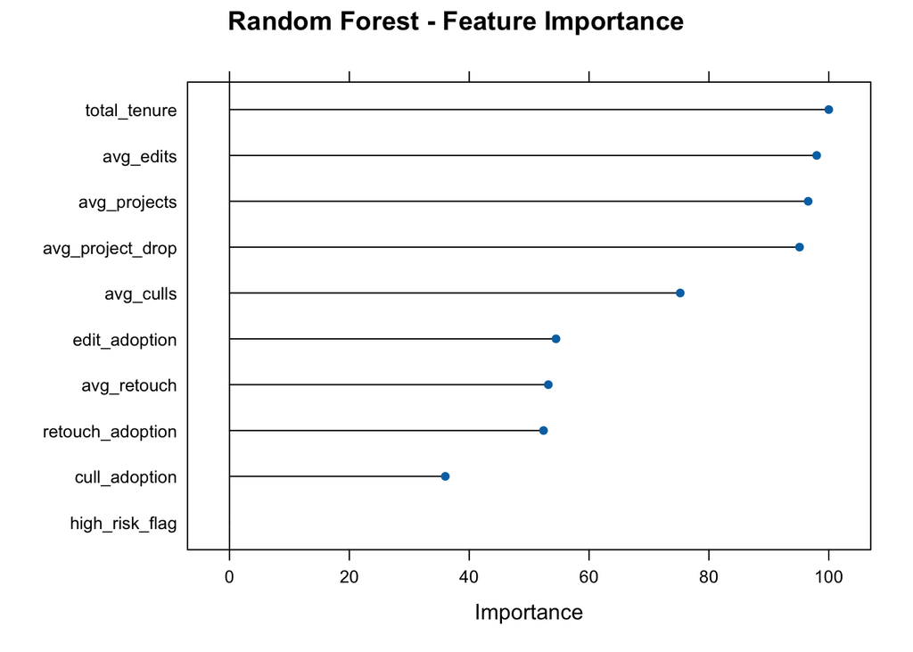

```r
# feature importance in driving churn
varImp(model_rf) %>% plot(main = "Random Forest - Feature Importance")
```

```r
# predict on test data
pred_rf <- predict(model_rf, newdata = test_data)

pred_rf_prob <- predict(model_rf, newdata = test_data, type = "prob")[, "Churned"]

# confusion matrix
cm_rf <- confusionMatrix(pred_rf, test_data$churned, positive = "Churned")

cm_rf
```

```
## Confusion Matrix and Statistics
##
##           Reference
## Prediction Retained Churned
##   Retained      972     338
##   Churned       396     728
##
##                Accuracy : 0.6984
##                  95% CI : (0.6798, 0.7166)
##     No Information Rate : 0.562
##     P-Value [Acc > NIR] : < 2e-16
##
##                   Kappa : 0.3911
##
##  Mcnemar's Test P-Value : 0.03539
##
##             Sensitivity : 0.6829
##             Specificity : 0.7105
##          Pos Pred Value : 0.6477
##          Neg Pred Value : 0.7420
##              Prevalence : 0.4380
##          Detection Rate : 0.2991
##    Detection Prevalence : 0.4618
##       Balanced Accuracy : 0.6967
##
##        'Positive' Class : Churned
##
```

```r
# AUC-ROC
roc_rf <- roc(test_data$churned, pred_rf_prob, levels = c("Retained", "Churned"))

auc(roc_rf)
```

```
## Area under the curve: 0.7579
```

**Interpretation:**

**1. Hyperparameter Tuning**

- The model was tested across 3 values of `mtry` (the number of features randomly considered at each tree split): 2, 6, and 10.
- `mtry = 2` was selected as optimal based on the highest AUC/ROC (0.766), despite higher `mtry` values producing slightly better sensitivity.

**2. Feature Importance**

- `total_tenure` (100) is the strongest predictor of churn, followed closely by `avg_edits` (97.98), `avg_projects` (96.57), and `avg_project_drop` (95.13), confirming that lifecycle stage and engagement trends are the most predictive signals.
- `high_risk_flag` scored 0, meaning it adds no additional predictive value beyond its underlying features that are are already included in the model (as expected).

**3. Model Performance**

- AUC = 0.7579, a slight improvement from the logistic regression model (0.7403), indicating that Random Forest better captures non-linear relationships in the data.
- Accuracy improved slightly to 69.8% (vs 68.5% in logistic regression).
- Sensitivity held steady at 68.3%, identifying the same proportion of actual churners as logistic regression.
- Specificity improved to 71.1% (vs 68.7% in logistic regression), suggesting that Random Forest is better at correctly identifying retained users, which helps reduce unnecessary retention spend on low-risk users.

## Model 3 - XGBoost

XGBoost: gradient-boosted trees, where each new tree corrects the errors of the previous one.

```r
# XGBoost requires a numeric matrix for predictors and numeric 0/1 values for the target variable
# prepare training and testing data (keep churned as factor for later evaluation)
train_xgb <- train_data %>%
  mutate(churned = factor(churned, levels = c("Retained", "Churned")))

test_xgb <- test_data %>%
  mutate(churned = factor(churned, levels = c("Retained", "Churned")))

# prepare training matrix
train_matrix <- xgb.DMatrix(
  data = as.matrix(train_xgb %>% select(-churned)),
  label = ifelse(train_xgb$churned == "Churned", 1, 0)
)

# prepare test matrix
test_matrix <- xgb.DMatrix(
  data = as.matrix(test_xgb %>% select(-churned)),
  label = ifelse(test_xgb$churned == "Churned", 1, 0)
)

# set parameters
xgb_params <- list(
  objective = "binary:logistic",
  eval_metric = "auc",
  eta = 0.1,
  max_depth = 5,
  subsample = 0.8,
  colsample_bytree = 0.8,
  min_child_weight = 1,
  gamma = 0
)

# set seed for reproducibility
set.seed(123)

# train with cross-validation to find best number of rounds
xgb_cv <- xgb.cv(
  params = xgb_params,
  data = train_matrix,
  nrounds = 200,
  nfold = 5,
  verbose = 0,
  early_stopping_rounds = 20
)

# use best_iteration if available, otherwise use round with highest test AUC
best_nrounds <- if (!is.null(xgb_cv$best_iteration) && length(xgb_cv$best_iteration) > 0) {
  xgb_cv$best_iteration
} else {
  which.max(xgb_cv$evaluation_log$test_auc_mean)
}

best_nrounds
```

```
## [1] 86
```

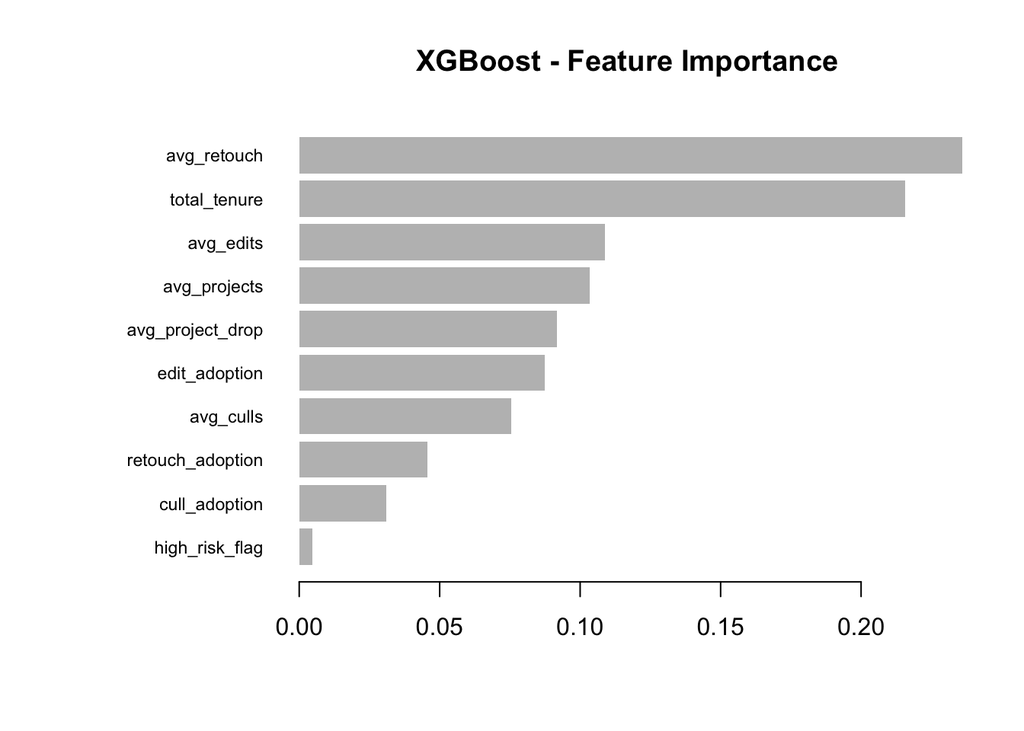

```r
# train final model using best number of rounds
model_xgb <- xgb.train(
  params = xgb_params,
  data = train_matrix,
  nrounds = best_nrounds,
  verbose = 0
)

# feature importance
xgb_importance <- xgb.importance(model = model_xgb)

xgb.plot.importance(xgb_importance, main = "XGBoost - Feature Importance")
```

```r
# predict on test set
pred_xgb_prob <- predict(model_xgb, newdata = test_matrix)

# convert probabilities to class labels using 0.5 threshold
pred_xgb <- factor(
  ifelse(pred_xgb_prob >= 0.5, "Churned", "Retained"),
  levels = c("Retained", "Churned")
)

# confusion matrix
cm_xgb <- confusionMatrix(pred_xgb, test_xgb$churned, positive = "Churned")

cm_xgb
```

```
## Confusion Matrix and Statistics
##
##           Reference
## Prediction Retained Churned
##   Retained      979     320
##   Churned       389     746
##
##                Accuracy : 0.7087
##                  95% CI : (0.6902, 0.7267)
##     No Information Rate : 0.562
##     P-Value [Acc > NIR] : < 2e-16
##
##                   Kappa : 0.4125
##
##  Mcnemar's Test P-Value : 0.01066
##
##             Sensitivity : 0.6998
##             Specificity : 0.7156
##          Pos Pred Value : 0.6573
##          Neg Pred Value : 0.7537
##              Prevalence : 0.4380
##          Detection Rate : 0.3065
##    Detection Prevalence : 0.4663
##       Balanced Accuracy : 0.7077
##
##        'Positive' Class : Churned
##
```

```r
# AUC-ROC
roc_xgb <- roc(test_xgb$churned, pred_xgb_prob, levels = c("Retained", "Churned"))

auc(roc_xgb)
```

```
## Area under the curve: 0.7796
```

**Interpretation:**

**1. Training & Tuning**

86 boosting rounds were identified as optimal, meaning the model built 86 sequential trees, each correcting the errors of the previous one, before performance stopped improving.

**2. Feature Importance**

- `avg_retouch` (0.236) and `total_tenure` (0.216) are the top 2 predictors, a slight change from Random Forest where `total_tenure` ranked first, suggesting XGBoost is picking up on retouching behaviour as a stronger differentiating signal than the other models.
- `avg_edits`, `avg_projects`, and `avg_project_drop` continue to rank highly, consistent with findings across all 3 models.
- `high_risk_flag` again scores near zero (0.005), further confirming it carries no independent predictive value beyond its underlying features.

**3. Model Performance**

- AUC = 0.7796 (highest across all 3 models) confirms that XGBoost best captures the complexity of churn behaviour in this dataset.
- Accuracy improved to 70.9%, sensitivity to 70%, and specificity to 71.6%, all being improvements over both previous models.
- The model is well-balanced between catching actual churners (70% sensitivity) and correctly clearing retained users (71.6% specificity), making it the most reliable model for risk scoring.

## Model Comparison

```r
# compile AUC scores for all 3 models
model_comparison <- data.frame(
  Model = c("Logistic Regression", "Random Forest", "XGBoost"),
  AUC = round(c(
    auc(roc_logit),
    auc(roc_rf),
    auc(roc_xgb)
  ), 4),
  Accuracy = round(c(
    cm_logit$overall["Accuracy"],
    cm_rf$overall["Accuracy"],
    cm_xgb$overall["Accuracy"]
  ), 4),
  Sensitivity = round(c(
    cm_logit$byClass["Sensitivity"],
    cm_rf$byClass["Sensitivity"],
    cm_xgb$byClass["Sensitivity"]
  ), 4),
  Specificity = round(c(
    cm_logit$byClass["Specificity"],
    cm_rf$byClass["Specificity"],
    cm_xgb$byClass["Specificity"]
  ), 4)
)

model_comparison
```

| Model | AUC | Accuracy | Sensitivity | Specificity |
| --- | --- | --- | --- | --- |
| Logistic Regression | 0.7403 | 0.6853 | 0.6829 | 0.6871 |
| Random Forest | 0.7579 | 0.6984 | 0.6829 | 0.7105 |
| XGBoost | 0.7796 | 0.7087 | 0.6998 | 0.7156 |

```r
# plot ROC curves for all 3 models
## step 1: combine all 3 ROC objects into a named list
roc_list <- list(
  "Logistic Regression" = roc_logit,
  "Random Forest" = roc_rf,
  "XGBoost" = roc_xgb
)
## step 2: plot all ROC curves together
ggplotly(
  ggroc(roc_list, linewidth = 0.8) +
    scale_color_manual(
      values = c(
        "Logistic Regression" = "#457B9D",
        "Random Forest" = "#2A9D8F",
        "XGBoost" = "#E63946"
      ),
      labels = c(
        paste("Logistic Regression (AUC =", round(auc(roc_logit), 3), ")"),
        paste("Random Forest (AUC =", round(auc(roc_rf), 3), ")"),
        paste("XGBoost (AUC =", round(auc(roc_xgb), 3), ")")
      )
    ) +
    geom_abline(slope = 1, intercept = 1,
                linetype = "dashed", color = "grey50") +
    labs(
      title = "ROC Curve Comparison - All Models",
      x = "Specificity",
      y = "Sensitivity",
      color = "Model"
    ) +
    theme_minimal()
)
```

[interactive chart not shown]

**Interpretation:**

- All 3 models perform meaningfully above random chance, with AUC scores ranging between 0.74 - 0.78.
- XGBoost is the best performing model across every metric - highest AUC (0.7796), accuracy (70.9%), sensitivity (70%), and specificity (71.6%) - and is therefore selected as the final model for risk tier stratification.

## Risk Tier Stratification using Best Model

We will use XGBoost (the best performing model).

```r
# prepare full user-level dataset as a numeric matrix
full_model_df <- model_data %>%
  select(-user_id, -churned) %>%
  mutate(avg_project_drop = replace_na(avg_project_drop, 0))

full_matrix <- xgb.DMatrix(
  data = as.matrix(full_model_df)
)

# generate churn probability scores for every user using XGBoost
churn_probs <- predict(model_xgb, newdata = full_matrix)

# view churn probability distribution
summary(churn_probs)
```

```
##     Min.  1st Qu.   Median     Mean  3rd Qu.     Max.
## 0.003708 0.218304 0.474069 0.436956 0.645590 0.946949
```

```r
# assign risk tiers using 0.4 and 0.7 as cut-offs
risk_scores <- model_data %>%
  select(user_id, churned) %>%
  mutate(
    churn_prob = churn_probs,
    risk_tier = case_when(
      churn_prob >= 0.7 ~ "High Risk",
      churn_prob >= 0.4 ~ "Medium Risk",
      TRUE ~ "Low Risk"
    ),
    risk_tier = factor(
      risk_tier,
      levels = c("Low Risk", "Medium Risk", "High Risk")
    )
  )

# view mix of users across tiers
risk_scores %>%
  count(risk_tier) %>%
  mutate(percentage = scales::percent(n / sum(n)))
```

| risk_tier | n | percentage |
| --- | --- | --- |
| Low Risk | 5120 | 42.05% |
| Medium Risk | 5001 | 41.08% |
| High Risk | 2054 | 16.87% |

**Interpretation:**

- XGBoost was used to generate individual churn probability scores between 0 and 1 for all 12,175 users.
- Users were then divided into 3 risk tiers using 0.4 and 0.7 as the cut-offs for assigning the risk tiers.
- The 3 tiers are distributed as:
  - Low Risk (42.1%, 5,120 users) - a healthy user base
  - Medium Risk (41.1%, 5,001 users) - watch and nurture
  - High Risk (16.9%, 2,054 users) - serious intervention needed

## Risk Tier Profiling & Benchmarking

```r
# join risk scores with full behavioural features for profiling
risk_profile <- risk_scores %>%
  left_join(model_data, by = "user_id")

# behavioural summary per tier
tier_summary <- risk_profile %>%
  group_by(risk_tier) %>%
  summarise(
    users = n(),
    actual_churn_rate = scales::percent(mean(churned.x), accuracy = 0.1),
    avg_churn_prob = round(mean(churn_prob), 3),
    avg_tenure = round(mean(total_tenure), 1),
    avg_projects = round(mean(avg_projects), 1),
    avg_edits = round(mean(avg_edits), 1),
    edit_adoption_pct = scales::percent(mean(edit_adoption), accuracy = 0.1),
    cull_adoption_pct = scales::percent(mean(cull_adoption), accuracy = 0.1),
    high_risk_pct = scales::percent(mean(high_risk_flag), accuracy = 0.1)
  )

tier_summary
```

| risk_tier | users | actual_churn_rate | avg_churn_prob | avg_tenure | avg_projects | avg_edits | edit_adoption_pct | cull_adoption_pct | high_risk_pct |
| --- | --- | --- | --- | --- | --- | --- | --- | --- | --- |
| Low Risk | 5120 | 15.4% | 0.186 | 8.8 | 11.5 | 7.8 | 85.6% | 73.5% | 18.8% |
| Medium Risk | 5001 | 57.0% | 0.561 | 3.9 | 6.0 | 3.3 | 66.7% | 67.6% | 31.3% |
| High Risk | 2054 | 82.6% | 0.760 | 3.4 | 4.2 | 1.7 | 35.3% | 49.0% | 52.8% |

```r
# plot churn probability distribution by risk tier
ggplotly(
  ggplot(risk_scores, aes(x = churn_prob, fill = risk_tier)) +
    geom_histogram(bins = 40, alpha = 0.8, position = "identity") +
    scale_fill_manual(values = c("#2A9D8F", "#F4A261", "#E63946")) +
    labs(
      title = "Churn Probability Distribution by Risk Tier",
      x = "Predicted Churn Probability",
      y = "Number of Users",
      fill = "Risk Tier"
    ) +
    theme_minimal()
)
```

[interactive chart not shown]

```r
# plot actual vs predicted churn rate per tier
## step 1: separate plot data for risk tiers
tier_plot_data <- risk_profile %>%
  group_by(risk_tier) %>%
  summarise(
    actual_churn_rate = mean(churned.x),
    avg_churn_prob = mean(churn_prob)
  ) %>%
  pivot_longer(
    cols = c(actual_churn_rate, avg_churn_prob),
    names_to = "metric",
    values_to = "value"
  ) %>%
  mutate(
    metric = recode(metric,
      actual_churn_rate = "Actual Churn Rate",
      avg_churn_prob = "Avg Predicted Probability"
    )
  )
## step 2: create plot
ggplotly(
  ggplot(tier_plot_data, aes(x = risk_tier, y = value, fill = metric)) +
    geom_col(position = "dodge", width = 0.8) +
    scale_y_continuous(labels = scales::percent_format()) +
    scale_fill_manual(values = c("#457B9D", "#E63946")) +
    labs(
      title = "Actual vs Predicted Churn Rate by Risk Tiers",
      x = "Risk Tier",
      y = "Rate / Probability",
      fill = "Metric"
    ) +
    theme_minimal()
)
```

[interactive chart not shown]

**Interpretation:**

- `Low Risk` users have:
  - lowest churn rate (15.4%)
  - longest average tenure (8.8 months)
  - highest project activity (11.5 projects, 7.8 edits)
  - strong feature adoption (85.6% editing, 73.5% culling)

*These are well-engaged users who have clearly found value in the product.*

- `Medium Risk` users sit in the middle with:
  - 57% churn rate
  - shorter tenure (3.9 months)
  - around 50% lower activity than Low-Risk users (6 projects, 3.3 edits)
  - moderately lower feature adoption (66.7% editing, 67.6% culling)

*They are active but have not yet demonstrated the consistent feature adoption seen in Low Risk users.*

- `High Risk` users show:
  - 82.6% churn rate
  - shortest tenure (3.4 months)
  - lowest project activity (4.2 projects, 1.7 edits)
  - significantly lower feature adoption (35.3% editing, 49% culling)

*This is consistent with early-stage users who have not yet realised product value.*